# Ford GoBike System Data Exploration

## Preliminary Wrangling

> Ford GoBike is the Bay Area's new bike share system, with thousands of public bikes for use across San Francisco, East Bay and San Jose. Our bike share is designed with convenience in mind; it’s a fun and affordable way to get around town. The data analyzed is from January, February and March of 2019 and was downloaded from https://s3.amazonaws.com/fordgobike-data/index.html

REMEMBER TO INSTALL geopandas (conda install geopandas), erlang (pip install python-erlang) and basemap (conda install basemap conda install basemap-data-hires)

```python
# import all packages and set plots to be embedded inline
import pandas as pd
import seaborn as sb
import numpy as np
import geopandas as gpd
import erlang
import zipfile
import os
os.environ["PROJ_LIB"]="C:\\Users\\All Users\\Anaconda3\\Library\\share"
from mpl_toolkits.basemap import Basemap
from matplotlib import pyplot as plt
from pandas.tseries.holiday import USFederalHolidayCalendar

%matplotlib inline
```

## Gathering

```python
fordgobike = pd.read_csv('201901-fordgobike-tripdata.zip')
fordgobike = fordgobike.append(pd.read_csv('201902-fordgobike-tripdata.zip'), ignore_index = True)
fordgobike = fordgobike.append(pd.read_csv('201903-fordgobike-tripdata.zip'), ignore_index = True)
```

## Assesing

#### Quality

- Records with null values in some fields, these records will be removed
- The fields bike_id, start_station_id and end_station_id should have data type object and not float
- The start_time and end_time should have data type datetime and not string
- The field member_birth_year should be integer and not float

```python
fordgobike.head()
```

|  | duration_sec | start_time | end_time | start_station_id | start_station_name | start_station_latitude | start_station_longitude | end_station_id | end_station_name | end_station_latitude | end_station_longitude | bike_id | user_type | member_birth_year | member_gender | bike_share_for_all_trip |
| --- | --- | --- | --- | --- | --- | --- | --- | --- | --- | --- | --- | --- | --- | --- | --- | --- |
| 0 | 80825 | 2019-01-31 17:57:44.6130 | 2019-02-01 16:24:49.8640 | 229.0 | Foothill Blvd at 42nd Ave | 37.775745 | -122.213037 | 196.0 | Grand Ave at Perkins St | 37.808894 | -122.256460 | 4861 | Subscriber | 1989.0 | Male | No |
| 1 | 65900 | 2019-01-31 20:58:33.8860 | 2019-02-01 15:16:54.1730 | 4.0 | Cyril Magnin St at Ellis St | 37.785881 | -122.408915 | 134.0 | Valencia St at 24th St | 37.752428 | -122.420628 | 5506 | Subscriber | 1989.0 | Male | No |
| 2 | 62633 | 2019-01-31 18:06:52.9240 | 2019-02-01 11:30:46.5300 | 245.0 | Downtown Berkeley BART | 37.870139 | -122.268422 | 157.0 | 65th St at Hollis St | 37.846784 | -122.291376 | 2717 | Customer | 1965.0 | Female | No |
| 3 | 44680 | 2019-01-31 19:46:09.7190 | 2019-02-01 08:10:50.3180 | 85.0 | Church St at Duboce Ave | 37.770083 | -122.429156 | 53.0 | Grove St at Divisadero | 37.775946 | -122.437777 | 4557 | Customer | 1974.0 | Male | No |
| 4 | 60709 | 2019-01-31 14:19:01.5410 | 2019-02-01 07:10:51.0650 | 16.0 | Steuart St at Market St | 37.794130 | -122.394430 | 28.0 | The Embarcadero at Bryant St | 37.787168 | -122.388098 | 2100 | Customer | NaN | NaN | No |

```python
fordgobike.shape
```

```
(631793, 16)
```

```python
fordgobike.info()
```

```
<class 'pandas.core.frame.DataFrame'>
RangeIndex: 631793 entries, 0 to 631792
Data columns (total 16 columns):
duration_sec               631793 non-null int64
start_time                 631793 non-null object
end_time                   631793 non-null object
start_station_id           631127 non-null float64
start_station_name         631127 non-null object
start_station_latitude     631793 non-null float64
start_station_longitude    631793 non-null float64
end_station_id             631127 non-null float64
end_station_name           631127 non-null object
end_station_latitude       631793 non-null float64
end_station_longitude      631793 non-null float64
bike_id                    631793 non-null int64
user_type                  631793 non-null object
member_birth_year          602085 non-null float64
member_gender              602088 non-null object
bike_share_for_all_trip    631793 non-null object
dtypes: float64(7), int64(2), object(7)
memory usage: 77.1+ MB
```

```python
fordgobike.duplicated().any()
```

```
False
```

```python
print(fordgobike['user_type'].value_counts())
print(fordgobike['member_gender'].value_counts())
print(fordgobike['bike_share_for_all_trip'].value_counts())
```

```
Subscriber    551599
Customer       80194
Name: user_type, dtype: int64
Male      446585
Female    143383
Other      12120
Name: member_gender, dtype: int64
No     576023
Yes     55770
Name: bike_share_for_all_trip, dtype: int64
```

#### Tidiness

- There are no real tidiness issues but for my analysis is better to extract the day of the week and the hour from start_time. The analysis will have a time granularity of hours.
- I will also add a column to specify if the day is weekday or weekend day and a column for holiday. It might be important to know which days are holydays as they might affect the behavior of the custumers
- For the multivariate analysis I will have to round the start latitud to multiples of 0.002 degrees (in SF Bay area 0.002 degrees of latitud are equivalent to an 1/8 of mile) and round the start longitud to multiples of 0.0025 degrees (in SF Bay area 0.0025 degrees of longitud are equivalent to an 1/8 of mile), this is needed to create a grid on top of a map of San Francisco

## Cleaning

#### copying dataframes

```python
fordgobike_clean = fordgobike.copy()
```

#### Define

Records with null values in some fields, these records will be removed

#### Code

```python
fordgobike_clean.dropna(inplace=True)
```

#### Test

```python
fordgobike_clean.isnull().sum().any()
```

```
False
```

#### Define

The fields bike_id, start_station_id and end_station_id should have data type object and not float

#### Code

```python
fordgobike_clean.bike_id = fordgobike_clean.bike_id.astype(str)
fordgobike_clean.start_station_id = fordgobike_clean.start_station_id.astype(str)
fordgobike_clean.end_station_id = fordgobike_clean.end_station_id.astype(str)
```

#### Test

```python
fordgobike_clean.info()
```

```
<class 'pandas.core.frame.DataFrame'>
Int64Index: 601429 entries, 0 to 631792
Data columns (total 16 columns):
duration_sec               601429 non-null int64
start_time                 601429 non-null object
end_time                   601429 non-null object
start_station_id           601429 non-null object
start_station_name         601429 non-null object
start_station_latitude     601429 non-null float64
start_station_longitude    601429 non-null float64
end_station_id             601429 non-null object
end_station_name           601429 non-null object
end_station_latitude       601429 non-null float64
end_station_longitude      601429 non-null float64
bike_id                    601429 non-null object
user_type                  601429 non-null object
member_birth_year          601429 non-null float64
member_gender              601429 non-null object
bike_share_for_all_trip    601429 non-null object
dtypes: float64(5), int64(1), object(10)
memory usage: 78.0+ MB
```

#### Define

The start_time and end_time should have data type datetime and not string

#### Code

```python
fordgobike_clean['start_time'] = pd.to_datetime(fordgobike_clean.start_time)
fordgobike_clean['end_time'] = pd.to_datetime(fordgobike_clean.end_time)
```

#### Test

```python
fordgobike_clean.info()
```

```
<class 'pandas.core.frame.DataFrame'>
Int64Index: 601429 entries, 0 to 631792
Data columns (total 16 columns):
duration_sec               601429 non-null int64
start_time                 601429 non-null datetime64[ns]
end_time                   601429 non-null datetime64[ns]
start_station_id           601429 non-null object
start_station_name         601429 non-null object
start_station_latitude     601429 non-null float64
start_station_longitude    601429 non-null float64
end_station_id             601429 non-null object
end_station_name           601429 non-null object
end_station_latitude       601429 non-null float64
end_station_longitude      601429 non-null float64
bike_id                    601429 non-null object
user_type                  601429 non-null object
member_birth_year          601429 non-null float64
member_gender              601429 non-null object
bike_share_for_all_trip    601429 non-null object
dtypes: datetime64[ns](2), float64(5), int64(1), object(8)
memory usage: 78.0+ MB
```

#### Define

The field member_birth_year should be integer and not float

#### Code

```python
fordgobike_clean.member_birth_year = fordgobike_clean.member_birth_year.astype(int)
```

#### Test

```python
fordgobike_clean.info()
```

```
<class 'pandas.core.frame.DataFrame'>
Int64Index: 601429 entries, 0 to 631792
Data columns (total 16 columns):
duration_sec               601429 non-null int64
start_time                 601429 non-null datetime64[ns]
end_time                   601429 non-null datetime64[ns]
start_station_id           601429 non-null object
start_station_name         601429 non-null object
start_station_latitude     601429 non-null float64
start_station_longitude    601429 non-null float64
end_station_id             601429 non-null object
end_station_name           601429 non-null object
end_station_latitude       601429 non-null float64
end_station_longitude      601429 non-null float64
bike_id                    601429 non-null object
user_type                  601429 non-null object
member_birth_year          601429 non-null int32
member_gender              601429 non-null object
bike_share_for_all_trip    601429 non-null object
dtypes: datetime64[ns](2), float64(4), int32(1), int64(1), object(8)
memory usage: 75.7+ MB
```

#### Define

There are no real tidiness issues but for my analysis is better to extract the day of the week and the time from start time.

#### Code

```python
# extracting date
fordgobike_clean['start_date']=fordgobike_clean['start_time'].dt.date
# extracting week day name
fordgobike_clean['week_day_name']=fordgobike_clean['start_time'].dt.day_name()
# adding flad for weekend day
fordgobike_clean['weekend']=fordgobike_clean['week_day_name'].apply(
    lambda weekday: True if weekday in ('Saturday','Sunday') else False)
# extracting time from start_time
fordgobike_clean['start_hour']=fordgobike_clean['start_time'].dt.hour
fordgobike_clean['duration_hour']=fordgobike_clean['duration_sec']/3600
```

```python
# adding flag for holyday
USHoliday = USFederalHolidayCalendar().holidays(
        start=fordgobike_clean['start_time'].min(), end=fordgobike_clean['start_time'].max())
fordgobike_clean['is_holiday'] = fordgobike_clean['start_date'].astype('datetime64').isin(USHoliday)
```

#### Test

```python
fordgobike_clean.head()
```

|  | duration_sec | start_time | end_time | start_station_id | start_station_name | start_station_latitude | start_station_longitude | end_station_id | end_station_name | end_station_latitude | ... | user_type | member_birth_year | member_gender | bike_share_for_all_trip | start_date | week_day_name | weekend | start_hour | duration_hour | is_holiday |
| --- | --- | --- | --- | --- | --- | --- | --- | --- | --- | --- | --- | --- | --- | --- | --- | --- | --- | --- | --- | --- | --- |
| 0 | 80825 | 2019-01-31 17:57:44.613 | 2019-02-01 16:24:49.864 | 229.0 | Foothill Blvd at 42nd Ave | 37.775745 | -122.213037 | 196.0 | Grand Ave at Perkins St | 37.808894 | ... | Subscriber | 1989 | Male | No | 2019-01-31 | Thursday | False | 17 | 22.451389 | False |
| 1 | 65900 | 2019-01-31 20:58:33.886 | 2019-02-01 15:16:54.173 | 4.0 | Cyril Magnin St at Ellis St | 37.785881 | -122.408915 | 134.0 | Valencia St at 24th St | 37.752428 | ... | Subscriber | 1989 | Male | No | 2019-01-31 | Thursday | False | 20 | 18.305556 | False |
| 2 | 62633 | 2019-01-31 18:06:52.924 | 2019-02-01 11:30:46.530 | 245.0 | Downtown Berkeley BART | 37.870139 | -122.268422 | 157.0 | 65th St at Hollis St | 37.846784 | ... | Customer | 1965 | Female | No | 2019-01-31 | Thursday | False | 18 | 17.398056 | False |
| 3 | 44680 | 2019-01-31 19:46:09.719 | 2019-02-01 08:10:50.318 | 85.0 | Church St at Duboce Ave | 37.770083 | -122.429156 | 53.0 | Grove St at Divisadero | 37.775946 | ... | Customer | 1974 | Male | No | 2019-01-31 | Thursday | False | 19 | 12.411111 | False |
| 5 | 6733 | 2019-01-31 22:35:50.813 | 2019-02-01 00:28:04.512 | 245.0 | Downtown Berkeley BART | 37.870139 | -122.268422 | 266.0 | Parker St at Fulton St | 37.862464 | ... | Subscriber | 1994 | Male | No | 2019-01-31 | Thursday | False | 22 | 1.870278 | False |

5 rows × 22 columns

#### Define

For the multivariate analysis I will have to round the start latitud to multiples of 0.002 degrees (in SF Bay area 0.002 degrees of latitud are equivalent to a 1/8 of mile) and round the start longitud to multiples of 0.0025 degrees (in SF Bay area 0.0025 degrees of longitud are equivalent to a 1/8 of mile), this is needed to create a grid on top of a map of San Francisco.

#### Code

```python
fordgobike_clean['start_latitude_grid']=0.002*round(fordgobike_clean['start_station_latitude']/0.002,0)
fordgobike_clean['start_longitude_grid']=0.0025*round(fordgobike_clean['start_station_longitude']/0.0025,0)
```

#### Test

```python
fordgobike_clean.head()
```

|  | duration_sec | start_time | end_time | start_station_id | start_station_name | start_station_latitude | start_station_longitude | end_station_id | end_station_name | end_station_latitude | ... | member_gender | bike_share_for_all_trip | start_date | week_day_name | weekend | start_hour | duration_hour | is_holiday | start_latitude_grid | start_longitude_grid |
| --- | --- | --- | --- | --- | --- | --- | --- | --- | --- | --- | --- | --- | --- | --- | --- | --- | --- | --- | --- | --- | --- |
| 0 | 80825 | 2019-01-31 17:57:44.613 | 2019-02-01 16:24:49.864 | 229.0 | Foothill Blvd at 42nd Ave | 37.775745 | -122.213037 | 196.0 | Grand Ave at Perkins St | 37.808894 | ... | Male | No | 2019-01-31 | Thursday | False | 17 | 22.451389 | False | 37.776 | -122.2125 |
| 1 | 65900 | 2019-01-31 20:58:33.886 | 2019-02-01 15:16:54.173 | 4.0 | Cyril Magnin St at Ellis St | 37.785881 | -122.408915 | 134.0 | Valencia St at 24th St | 37.752428 | ... | Male | No | 2019-01-31 | Thursday | False | 20 | 18.305556 | False | 37.786 | -122.4100 |
| 2 | 62633 | 2019-01-31 18:06:52.924 | 2019-02-01 11:30:46.530 | 245.0 | Downtown Berkeley BART | 37.870139 | -122.268422 | 157.0 | 65th St at Hollis St | 37.846784 | ... | Female | No | 2019-01-31 | Thursday | False | 18 | 17.398056 | False | 37.870 | -122.2675 |
| 3 | 44680 | 2019-01-31 19:46:09.719 | 2019-02-01 08:10:50.318 | 85.0 | Church St at Duboce Ave | 37.770083 | -122.429156 | 53.0 | Grove St at Divisadero | 37.775946 | ... | Male | No | 2019-01-31 | Thursday | False | 19 | 12.411111 | False | 37.770 | -122.4300 |
| 5 | 6733 | 2019-01-31 22:35:50.813 | 2019-02-01 00:28:04.512 | 245.0 | Downtown Berkeley BART | 37.870139 | -122.268422 | 266.0 | Parker St at Fulton St | 37.862464 | ... | Male | No | 2019-01-31 | Thursday | False | 22 | 1.870278 | False | 37.870 | -122.2675 |

5 rows × 24 columns

## Storing clean data

```python
fordgobike_clean.to_csv('fordgobike.csv', encoding = 'utf-8', index=False, compression='zip')
os.rename('fordgobike.csv', 'fordgobike.zip')
```

```python
# load the clean dataframe if you need to re run from this point
fordgobike_clean = pd.read_csv('fordgobike.zip')
```

## Analysis

### What is the structure of your dataset?

> The dataset contains one record for each time a bike is used that specifies start time, end time and duration of the trip as well as start and end location of the trip. The data also provides basic information of the user like gender, year of birth, suscriber or casual costumer.

### What is/are the main feature(s) of interest in your dataset?

> The location and user information can give insights of the demographic of the costumers where they are geographically, start and end time in conjuntion with location can show where and when are used more. The previous mentioned features can be used to position the bikes in the locations where they are most needed when they are more needed.

### What features in the dataset do you think will help support your investigation into your feature(s) of interest?

#### Usually customer behavior for any service is different between weekends, weekdays and holidays, for this reason I will split the data in wekkend data and weekday data excluding holidays for this analysis

```python
# filtering weekdays only (excluding holidays)
fordgobike_weekday = fordgobike_clean.query("weekend == False & is_holiday ==False")
fordgobike_weekday.shape
```

```
(484194, 24)
```

```python
# filtering weekends only (excluding holidays)
fordgobike_weekend = fordgobike_clean.query("weekend == True & is_holiday ==False")
fordgobike_weekend.shape
```

```
(107082, 24)
```

## Univariate Exploration

#### Customer gender distribution

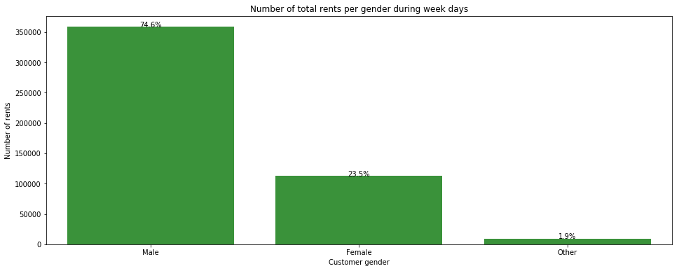

```python
gen_order = fordgobike_weekday['member_gender'].value_counts().index
n_customer_weekday = fordgobike_weekday.shape[0]
gen_weekday_count = fordgobike_weekday['member_gender'].value_counts()
# Female vs Male distribution during weekdays
plt.figure(figsize=(16,6));
ax = sb.countplot(data = fordgobike_weekday, x = 'member_gender', color = base_color, order = gen_order);
ax.set(xlabel='Customer gender', ylabel='Number of rents', title = 'Number of total rents per gender during week days');

locs, labels = plt.xticks();

# loop through each pair of locations and labels
for loc, label in zip(locs, labels):
    # get the text property for the label to get the correct count
    count = gen_weekday_count[label.get_text()]
    pct_string = '{:0.1f}%'.format(100*count/n_customer_weekday)

    # print the annotation just below the top of the bar
    plt.text(loc, count-8, pct_string, ha = 'center', color = 'black')
```

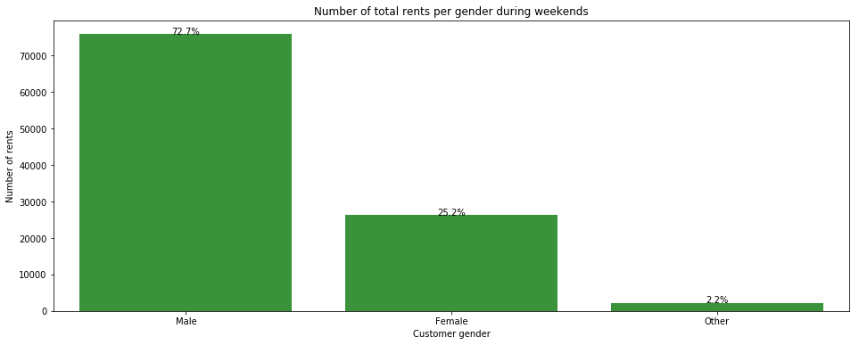

```python
n_customer_weekend = fordgobike_weekend.shape[0]
gen_weekend_count = fordgobike_weekend['member_gender'].value_counts()
# Female vs Male distribution during weekdays
plt.figure(figsize=(16,6));
ax = sb.countplot(data = fordgobike_weekend, x = 'member_gender', color = base_color, order = gen_order);
ax.set(xlabel='Customer gender', ylabel='Number of rents', title = 'Number of total rents per gender during weekends');

locs, labels = plt.xticks();

# loop through each pair of locations and labels
for loc, label in zip(locs, labels):
    # get the text property for the label to get the correct count
    count = gen_weekend_count[label.get_text()]
    pct_string = '{:0.1f}%'.format(100*count/n_customer_weekend)

    # print the annotation just below the top of the bar
    plt.text(loc, count-8, pct_string, ha = 'center', color = 'black')
```

- The 2 charts above show that male customers account for almost 3/4 of all customers indicating that females are not as interested in this service as males. If Ford gobike research why females use this service less than males and make changes based on the results of such investigation then there is a potential increase of 50% in the total number of users (supossing that Ford gobike could atract as many female users as male users).

## Customer user type distribution

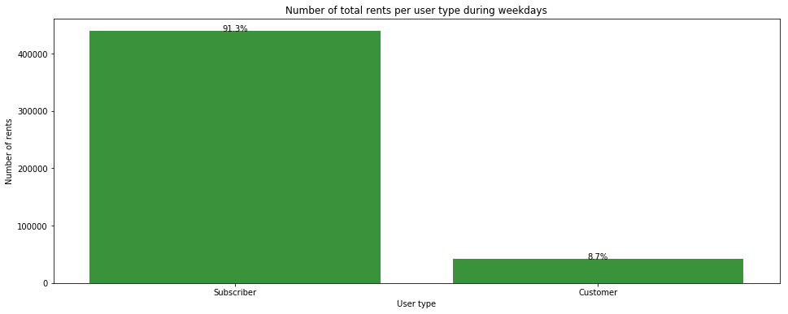

```python
user_type_order = fordgobike_weekday['user_type'].value_counts().index
n_customer_weekday = fordgobike_weekday.shape[0]
user_type_weekday_count = fordgobike_weekday['user_type'].value_counts()
# Customer vs Suscriber distribution during weekdays
plt.figure(figsize=(16,6));
ax = sb.countplot(data = fordgobike_weekday, x = 'user_type', color = base_color, order = user_type_order);
ax.set(xlabel='User type', ylabel='Number of rents', title = 'Number of total rents per user type during weekdays');
locs, labels = plt.xticks();

# loop through each pair of locations and labels
for loc, label in zip(locs, labels):
    # get the text property for the label to get the correct count
    count = user_type_weekday_count[label.get_text()]
    pct_string = '{:0.1f}%'.format(100*count/n_customer_weekday)

    # print the annotation just below the top of the bar
    plt.text(loc, count-8, pct_string, ha = 'center', color = 'black')
```

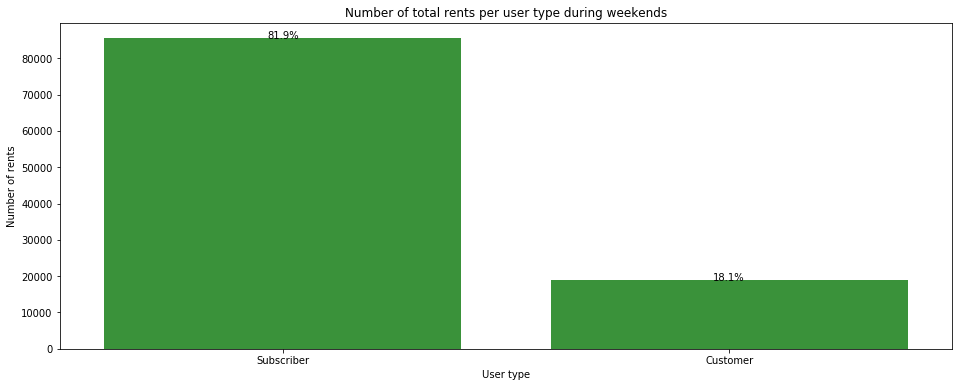

```python
n_customer_weekend = fordgobike_weekend.shape[0]
user_type_weekend_count = fordgobike_weekend['user_type'].value_counts()
# Customer vs Suscriber distribution during weekdays
plt.figure(figsize=(16,6));
ax = sb.countplot(data = fordgobike_weekend, x = 'user_type', color = base_color, order = user_type_order);
ax.set(xlabel='User type', ylabel='Number of rents', title = 'Number of total rents per user type during weekends');
locs, labels = plt.xticks();

# loop through each pair of locations and labels
for loc, label in zip(locs, labels):
    # get the text property for the label to get the correct count
    count = user_type_weekend_count[label.get_text()]
    pct_string = '{:0.1f}%'.format(100*count/n_customer_weekend)

    # print the annotation just below the top of the bar
    plt.text(loc, count-8, pct_string, ha = 'center', color = 'black')
```

- More than 80% of users are regular users (subscribers), it is easier to identify patterns of use and preferences in regular customers (subscribers) than random customers (non-subscribers). Finding these patterns or insights can offer an idea on what changes to make on the service or the bikes themselves to better suit the preferences of the subscribers, a more satisfying experience means higher customer loyalty.

#### Rent duration distribution and average rent duration

```
0.19060382993868624
```

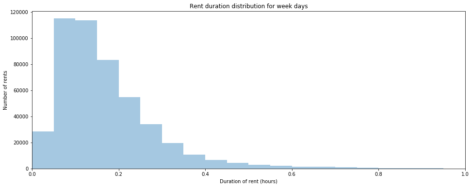

```python
base_color = sb.color_palette()[2]
bins = np.arange(0, 1, 0.05)
plt.figure(figsize=(16,6));
plt.xlim(0,1)
ax = sb.distplot(fordgobike_weekday['duration_hour'],kde = False, bins=bins);
ax.set(xlabel='Duration of rent (hours)', ylabel='Number of rents', title = 'Rent duration distribution for week days');
fordgobike_weekday['duration_hour'].mean()
```

```
0.2668043207801299
```

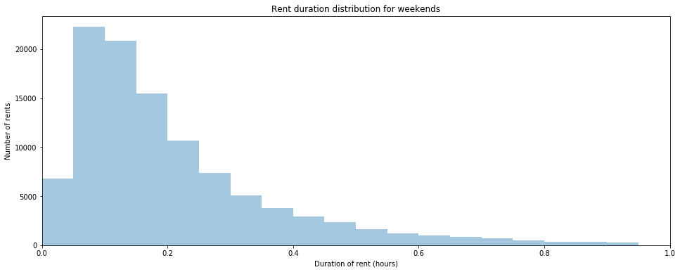

```python
plt.figure(figsize=(16,6));
plt.xlim(0,1)
ax = sb.distplot(fordgobike_weekend['duration_hour'],kde = False, bins=bins);
ax.set(xlabel='Duration of rent (hours)', ylabel='Number of rents', title = 'Rent duration distribution for weekends');
fordgobike_weekend['duration_hour'].mean()
```

There are some outliner values for duration_hour in the dataset, still the data shows an strong preferance for shor trips of 0.19 hours during weekdays and 0.27 hours during weekends. For the rest of the analysis I will remove all records with duration_hour greater than 1 hour.

```python
# removing records with duration_hour greater than 1 hour
fordgobike_weekday=fordgobike_weekday[fordgobike_weekday['duration_hour']<=1]
fordgobike_weekend=fordgobike_weekend[fordgobike_weekend['duration_hour']<=1]
```

```python
fordgobike_weekday.info()
```

```
<class 'pandas.core.frame.DataFrame'>
Int64Index: 480914 entries, 5 to 601428
Data columns (total 24 columns):
duration_sec               480914 non-null int64
start_time                 480914 non-null object
end_time                   480914 non-null object
start_station_id           480914 non-null float64
start_station_name         480914 non-null object
start_station_latitude     480914 non-null float64
start_station_longitude    480914 non-null float64
end_station_id             480914 non-null float64
end_station_name           480914 non-null object
end_station_latitude       480914 non-null float64
end_station_longitude      480914 non-null float64
bike_id                    480914 non-null int64
user_type                  480914 non-null object
member_birth_year          480914 non-null int64
member_gender              480914 non-null object
bike_share_for_all_trip    480914 non-null object
start_date                 480914 non-null object
week_day_name              480914 non-null object
weekend                    480914 non-null bool
start_hour                 480914 non-null int64
duration_hour              480914 non-null float64
is_holiday                 480914 non-null bool
start_latitude_grid        480914 non-null float64
start_longitude_grid       480914 non-null float64
dtypes: bool(2), float64(9), int64(4), object(9)
memory usage: 105.3+ MB
```

## Bivariate Exploration

### Gender and user type distribution

```python
# weekday
gender_usertype_weekday = fordgobike_weekday.groupby(['member_gender','user_type'],
                                      as_index=False)['bike_id'].count()
gender_usertype_weekday = gender_usertype_weekday.rename(columns={'bike_id': 'rent_pct'})
gender_usertype_weekday['rent_pct']=round(gender_usertype_weekday['rent_pct']/gender_usertype_weekday['rent_pct'].sum(),2)

# weekend
gender_usertype_weekend = fordgobike_weekend.groupby(['member_gender','user_type'],
                                      as_index=False)['bike_id'].count()
gender_usertype_weekend = gender_usertype_weekend.rename(columns={'bike_id': 'rent_pct'})
gender_usertype_weekend['rent_pct']=round(gender_usertype_weekend['rent_pct']/gender_usertype_weekend['rent_pct'].sum(),2)

gender_usertype_weekend.head()
```

|  | member_gender | user_type | rent_pct |
| --- | --- | --- | --- |
| 0 | Female | Customer | 0.06 |
| 1 | Female | Subscriber | 0.19 |
| 2 | Male | Customer | 0.12 |
| 3 | Male | Subscriber | 0.61 |
| 4 | Other | Customer | 0.00 |

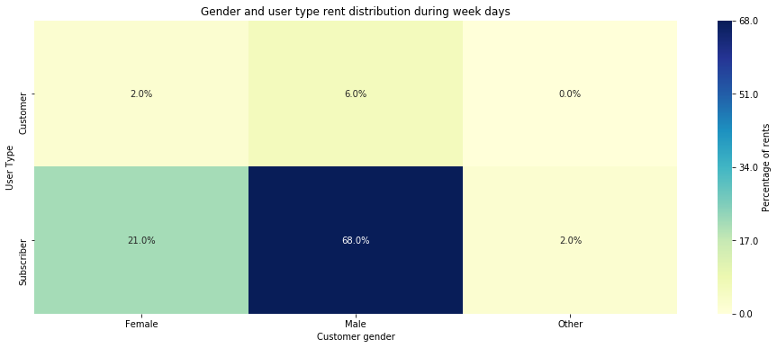

```python
result = gender_usertype_weekday.pivot(index='user_type', columns='member_gender', values='rent_pct')
plt.figure(figsize=(16,6));
ax = sb.heatmap(result, cmap="YlGnBu", cbar_kws={'label': 'Percentage of rents'}, annot = result.values, fmt = '.1%',)
ax.set(xlabel='Customer gender', ylabel='User Type', title = 'Gender and user type rent distribution during week days');
cbar = ax.collections[0].colorbar
cbar.set_ticks(np.arange(0, gender_usertype_weekday['rent_pct'].max()+0.01, gender_usertype_weekday['rent_pct'].max()/4))
cbar.set_ticklabels(np.arange(0, 1+(100*gender_usertype_weekday['rent_pct'].max()), 100*gender_usertype_weekday['rent_pct'].max()/4))
```

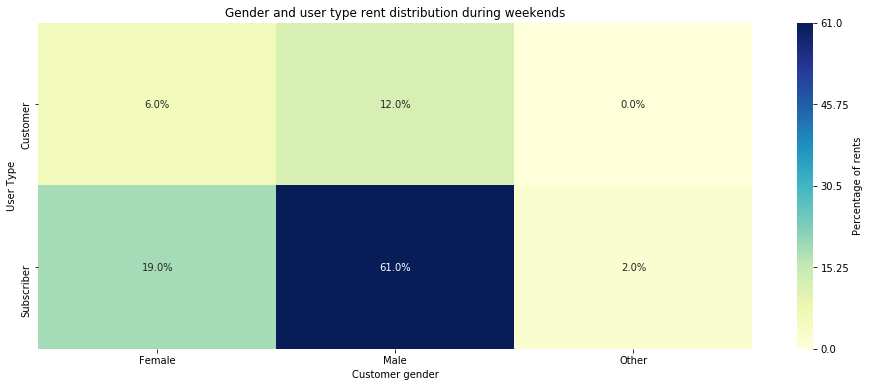

```python
result = gender_usertype_weekend.pivot(index='user_type', columns='member_gender', values='rent_pct')
plt.figure(figsize=(16,6));
ax = sb.heatmap(result, cmap="YlGnBu", cbar_kws={'label': 'Percentage of rents'}, annot = result.values, fmt = '.1%',)
ax.set(xlabel='Customer gender', ylabel='User Type', title = 'Gender and user type rent distribution during weekends');
cbar = ax.collections[0].colorbar
cbar.set_ticks(np.arange(0, gender_usertype_weekend['rent_pct'].max()+0.01, gender_usertype_weekend['rent_pct'].max()/4))
cbar.set_ticklabels(np.arange(0, 1+(100*gender_usertype_weekend['rent_pct'].max()), 100*gender_usertype_weekend['rent_pct'].max()/4))
```

- The 2 charts above reveal some of the same information that we found in the univariate analysis: Male Subscriber account for the majority of users with 61% of all weekend rents and 68% of week days rents.

#### Number of users per hour (erlangs)

> For this analysis I will define an erlang as 1 bike that has been used for 1 hour.

```python
# Calculating erlangs per hour
# Weekdays
weekday_usage = fordgobike_weekday.groupby('start_hour',as_index=False)['duration_hour'].sum()
weekday_count = fordgobike_weekday['start_date'].nunique()
# the previous 2 lines calculate the total usage per hour of all week days but,
# I am interested in the average usage per hour which is calculated in the next line
weekday_usage['duration_hour']=weekday_usage['duration_hour']/weekday_count

# Weekends
weekend_usage = fordgobike_weekend.groupby('start_hour',as_index=False)['duration_hour'].sum()
weekend_count = fordgobike_weekend['start_date'].nunique()
# the previous 2 lines calculate the total usage per hour of all weekend days but,
# I am interested in the average usage per hour which is calculated in the next line
weekend_usage['duration_hour']=weekend_usage['duration_hour']/weekend_count
```

```python
base_color = sb.color_palette()[2]
second_color = sb.color_palette()[3]
```

```
Busy hour erlangs = 178.71871863799373, busy hour minimum required bikes = 215
```

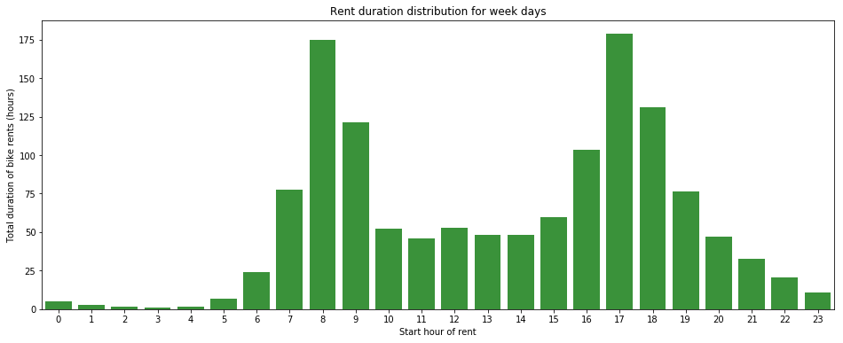

```python
# Erlangsper hour during weekdays
plt.figure(figsize=(16,6));
ax = sb.barplot(data=weekday_usage, x='start_hour', y='duration_hour', color = base_color);
ax.set(xlabel='Start hour of rent', ylabel='Total duration of bike rents (hours)', title = 'Rent duration distribution for week days');
busy_hour_erl = weekday_usage['duration_hour'].max()
# minimum required bikes during busy hour for 1% unavailability
min_required_bikes = erlang.extended_b_lines(busy_hour_erl, 0.001)
print(f'Busy hour erlangs = {busy_hour_erl}, busy hour minimum required bikes = {min_required_bikes}')
```

```
85.13250000000023
```

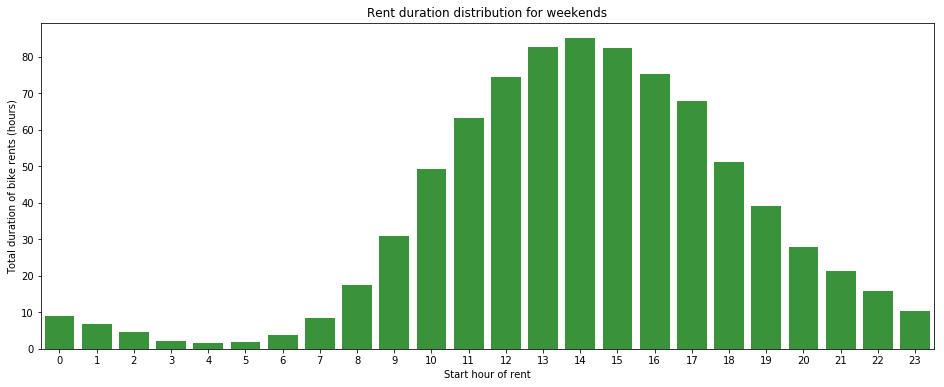

```python
# Erlangsper hour during weekends
plt.figure(figsize=(16,6));
ax = sb.barplot(data=weekend_usage, x='start_hour', y='duration_hour', color = base_color)
ax.set(xlabel='Start hour of rent', ylabel='Total duration of bike rents (hours)', title = 'Rent duration distribution for weekends');
weekend_usage['duration_hour'].max()
```

> The charts above shows that the hour of highest usage is 5pm during weekdays with an average of 178.8 erlangs of use at that hour.

> The above result is based only on capacity and demand and doesn't consider how far is the bike from the customer. The multivariate analysis will dig deeper into capacity, demand and location.

## Multivariate Exploration

#### Number of users per hour (erlangs) per location

> This is a similar analysis than the bivariate analysis but I will focus on 8am and 5pm of weekdays because they are the hours of highest use. I will use the latitud and longitud to show the results in a map.

```python
weekday_count = fordgobike_weekday['start_date'].nunique()
# Filtering for 8am weekdays
weekday_8am = fordgobike_weekday.query("start_hour == 8")
# Calculating the usage per location at 8am
weekday_8am_loc = weekday_8am.groupby(['start_hour','start_latitude_grid','start_longitude_grid'],
                                      as_index=False)['duration_hour'].sum()
# Calculating the average per day for 8am
weekday_8am_loc['duration_hour']=weekday_8am_loc['duration_hour']/weekday_count
# calculating minimum required bikes (at 1% unavailability) by location at 8am
weekday_8am_loc['min_required_bikes'] = weekday_8am_loc['duration_hour'].apply(
    lambda duration: erlang.extended_b_lines(duration, 0.001))



# Filtering for 5pm weekdays
weekday_5pm = fordgobike_weekday.query("start_hour == 17")
# Calculating the usage per location at 5pm
weekday_5pm_loc = weekday_5pm.groupby(['start_hour','start_latitude_grid','start_longitude_grid'],
                                      as_index=False)['duration_hour'].sum()
# Calculating the average per day for 5pm
weekday_5pm_loc['duration_hour']=weekday_5pm_loc['duration_hour']/weekday_count
# calculating minimum required bikes (at 1% unavailability) by location at 5pm
weekday_5pm_loc['min_required_bikes'] = weekday_5pm_loc['duration_hour'].apply(
    lambda duration: erlang.extended_b_lines(duration, 0.001))
```

```python
weekday_5pm_loc.head()
```

|  | start_hour | start_latitude_grid | start_longitude_grid | duration_hour | min_required_bikes |
| --- | --- | --- | --- | --- | --- |
| 0 | 17 | 37.322 | -121.8875 | 0.005170 | 2 |
| 1 | 17 | 37.322 | -121.8800 | 0.010040 | 2 |
| 2 | 17 | 37.324 | -121.8750 | 0.086393 | 3 |
| 3 | 17 | 37.326 | -121.8900 | 0.104341 | 3 |
| 4 | 17 | 37.326 | -121.8775 | 0.392728 | 4 |

The erlang B formula must roundup the results to the nearest integer because you cannot have 1.5 bikes in a given location. The roundup of the erlang B formula generates a new minimum required number of bikes during busy hour

```python
min_required_bikes_8am = weekday_8am_loc['min_required_bikes'].sum()
print(f'Busy hour minimum required bikes considering geographical distribution of users at 5pm is {min_required_bikes_8am}')
```

```
Busy hour minimum required bikes considering geographical distribution of users at 5pm is 1394
```

```python
min_required_bikes_5pm = weekday_5pm_loc['min_required_bikes'].sum()
print(f'Busy hour minimum required bikes considering geographical distribution of users at 5pm is {min_required_bikes_5pm}')
```

```
Busy hour minimum required bikes considering geographical distribution of users at 5pm is 1381
```

#### 8am Map of minimum required bikes

```python
lat=weekday_8am_loc['start_latitude_grid'].values
lon=weekday_8am_loc['start_longitude_grid'].values
bikes = weekday_8am_loc['min_required_bikes'].values
```

[figure not shown]

```python
fig = plt.figure(figsize=(24, 14))

# Creating map window
m = Basemap(projection='lcc',
            resolution='f',
            lat_0=37.8,
            lon_0=-122.33,
            urcrnrlon=-122.21,
            urcrnrlat=37.89,
            llcrnrlon=-122.46,
            llcrnrlat=37.72,
            epsg = 4326)

# adding streets background image
m.arcgisimage(service='ESRI_StreetMap_World_2D', xpixels = 1000, verbose= False);

# adding grid with number of bikes required
m.scatter(lon,lat, latlon=True,c=bikes,s=100,marker='s',cmap='tab20b', alpha=0.7);

# adding color band legend
plt.colorbar(label=r'required bikes')
plt.clim(0, weekday_8am_loc['min_required_bikes'].max())
```

#### 5pm Map of minimum required bikes

```python
lat=weekday_5pm_loc['start_latitude_grid'].values
lon=weekday_5pm_loc['start_longitude_grid'].values
bikes = weekday_5pm_loc['min_required_bikes'].values
```

[figure not shown]

```python
fig = plt.figure(figsize=(24, 14))

# Creating map window
m = Basemap(projection='lcc',
            resolution='f',
            lat_0=37.8,
            lon_0=-122.33,
            urcrnrlon=-122.21,
            urcrnrlat=37.89,
            llcrnrlon=-122.46,
            llcrnrlat=37.72,
            epsg = 4326)

# adding streets background image
m.arcgisimage(service='ESRI_StreetMap_World_2D', xpixels = 1000, verbose= False);

# adding grid with number of bikes required
m.scatter(lon,lat, latlon=True,c=bikes,s=100,marker='s',cmap='tab20b', alpha=0.7);

# adding color band legend
plt.colorbar(label=r'required bikes')
plt.clim(0, weekday_5pm_loc['min_required_bikes'].max())
```